# GARCH_temperatures

Sean Ammirati

November 8, 2016

```r
library(vars)
data(Canada)
```

## First Look at Data

```r
can <- Canada
head(can)
```

[output not shown]

```r
summary(can)
```

```
##        e              prod             rw              U
##  Min.   :928.6   Min.   :401.3   Min.   :386.1   Min.   : 6.700
##  1st Qu.:935.4   1st Qu.:404.8   1st Qu.:423.9   1st Qu.: 7.782
##  Median :946.0   Median :406.5   Median :444.4   Median : 9.450
##  Mean   :944.3   Mean   :407.8   Mean   :440.8   Mean   : 9.321
##  3rd Qu.:950.0   3rd Qu.:410.7   3rd Qu.:461.1   3rd Qu.:10.607
##  Max.   :961.8   Max.   :418.0   Max.   :470.0   Max.   :12.770
```

First, we import the dataset into a variable called can. We get some basic statistics (the quartiles, median and mean) with the summary function. I first try a VAR model of high dimension, where p=5, but this proves to have many insignificant variables. I then use VARselect to find the best model to fit.

```r
mod<-VAR(Canada,5,type="both")
summary(mod)
```

```
##
## VAR Estimation Results:
## =========================
## Endogenous variables: e, prod, rw, U
## Deterministic variables: both
## Sample size: 79
## Log Likelihood: -121.4
## Roots of the characteristic polynomial:
## 0.977 0.977 0.8628 0.8628 0.802 0.802 0.7625 0.7625 0.7362 0.7362 0.7192 0.7192 0.7135 0.6171 0.6171 0.6074 0.6074 0.4799 0.4799 0.4259
## Call:
## VAR(y = Canada, p = 5, type = "both")
##
##
## Estimation results for equation e:
## ==================================
## e = e.l1 + prod.l1 + rw.l1 + U.l1 + e.l2 + prod.l2 + rw.l2 + U.l2 + e.l3 + prod.l3 + rw.l3 + U.l3 + e.l4 + prod.l4 + rw.l4 + U.l4 + e.l5 + prod.l5 + rw.l5 + U.l5 + const + trend
##
##           Estimate Std. Error t value Pr(>|t|)
## e.l1     1.768e+00  1.893e-01   9.338 4.35e-13 ***
## prod.l1  1.887e-01  6.994e-02   2.698  0.00916 **
## rw.l1   -9.063e-02  6.184e-02  -1.466  0.14825
## U.l1     2.952e-01  2.325e-01   1.270  0.20933
## e.l2    -9.293e-01  2.993e-01  -3.104  0.00297 **
## prod.l2 -4.384e-02  1.058e-01  -0.414  0.68016
## rw.l2    4.004e-03  7.759e-02   0.052  0.95902
## U.l2    -1.967e-02  2.677e-01  -0.073  0.94169
## e.l3     2.731e-01  3.191e-01   0.856  0.39556
## prod.l3 -6.042e-02  1.059e-01  -0.571  0.57051
## rw.l3   -2.780e-03  7.834e-02  -0.035  0.97182
## U.l3     2.408e-01  2.657e-01   0.907  0.36847
## e.l4     2.247e-01  3.003e-01   0.748  0.45732
## prod.l4  4.400e-02  1.008e-01   0.436  0.66424
## rw.l4    2.512e-02  7.501e-02   0.335  0.73899
## U.l4     6.709e-03  2.710e-01   0.025  0.98034
## e.l5    -1.975e-01  2.075e-01  -0.952  0.34523
## prod.l5 -2.961e-02  6.921e-02  -0.428  0.67035
## rw.l5    3.175e-02  6.153e-02   0.516  0.60790
## U.l5    -1.910e-01  2.274e-01  -0.840  0.40439
## const   -1.584e+02  9.073e+01  -1.746  0.08625 .
## trend   -3.113e-02  2.055e-02  -1.515  0.13530
```

[output cut: 116 more lines]

```
##
##
## Covariance matrix of residuals:
##             e      prod       rw         U
## e     0.11867 -0.029090 -0.03977 -0.072306
## prod -0.02909  0.417084  0.01150  0.002056
## rw   -0.03977  0.011498  0.52420  0.031315
## U    -0.07231  0.002056  0.03131  0.082468
##
## Correlation matrix of residuals:
##            e     prod       rw        U
## e     1.0000 -0.13075 -0.15947 -0.73090
## prod -0.1308  1.00000  0.02459  0.01108
## rw   -0.1595  0.02459  1.00000  0.15061
## U    -0.7309  0.01108  0.15061  1.00000
```

```r
VARselect(Canada,lag.max=10,type="both")
```

```
## $selection
## AIC(n)  HQ(n)  SC(n) FPE(n)
##      3      2      1      3
##
## $criteria
##                   1            2             3            4            5
## AIC(n) -6.457999837 -6.862930587 -6.9695915550 -6.826230019 -6.696865092
## HQ(n)  -6.159906898 -6.366109023 -6.2740413655 -5.931951204 -5.603857651
## SC(n)  -5.710735482 -5.617489996 -5.2259747277 -4.584436956 -3.956895792
## FPE(n)  0.001570168  0.001052827  0.0009575467  0.001128994  0.001329669
##                   6           7            8            9           10
## AIC(n) -6.687175990 -6.55982329 -6.584746129 -6.493397603 -6.523612352
## HQ(n)  -5.395439924 -5.06935860 -4.895552811 -4.605475660 -4.436961783
## SC(n)  -3.449030454 -2.82350152 -2.350248120 -1.760723357 -1.292761870
## FPE(n)  0.001412901  0.00172546  0.001859561  0.002330702  0.002704777
```

# Using VARselect to fit models

The results are conflicting. Based on the AIC and FPE, I should use a VAR model with p = 3. According to SC, I should use a VAR model wth p = 1. I try all alternatives below.

```r
mod2<-VAR(Canada,2,type="both")
mod3<-VAR(Canada,1,type="both")
mod4<-VAR(Canada,3,type="both")
summary(mod2)
```

```
##
## VAR Estimation Results:
## =========================
## Endogenous variables: e, prod, rw, U
## Deterministic variables: both
## Sample size: 82
## Log Likelihood: -170.726
## Roots of the characteristic polynomial:
## 0.9071 0.9071 0.9037 0.7092 0.7092 0.2549 0.166 0.166
## Call:
## VAR(y = Canada, p = 2, type = "both")
##
##
## Estimation results for equation e:
## ==================================
## e = e.l1 + prod.l1 + rw.l1 + U.l1 + e.l2 + prod.l2 + rw.l2 + U.l2 + const + trend
##
##           Estimate Std. Error t value Pr(>|t|)
## e.l1     1.636e+00  1.510e-01  10.830  < 2e-16 ***
## prod.l1  1.716e-01  6.280e-02   2.733  0.00789 **
## rw.l1   -6.006e-02  5.628e-02  -1.067  0.28947
## U.l1     2.740e-01  2.055e-01   1.333  0.18661
## e.l2    -4.842e-01  1.648e-01  -2.938  0.00443 **
## prod.l2 -9.766e-02  6.747e-02  -1.448  0.15207
## rw.l2    1.689e-03  5.621e-02   0.030  0.97611
## U.l2     1.433e-01  2.108e-01   0.680  0.49886
## const   -1.510e+02  6.921e+01  -2.181  0.03244 *
## trend   -5.706e-03  1.652e-02  -0.345  0.73077
## ---
## Signif. codes:  0 '***' 0.001 '**' 0.01 '*' 0.05 '.' 0.1 ' ' 1
##
##
## Residual standard error: 0.365 on 72 degrees of freedom
## Multiple R-Squared: 0.9985,  Adjusted R-squared: 0.9983
## F-statistic:  5435 on 9 and 72 DF,  p-value: < 2.2e-16
##
##
## Estimation results for equation prod:
## =====================================
## prod = e.l1 + prod.l1 + rw.l1 + U.l1 + e.l2 + prod.l2 + rw.l2 + U.l2 + const + trend
```

[output cut: 68 more lines]

```
##
##
## Covariance matrix of residuals:
##              e      prod       rw         U
## e     0.133242 -0.004968 -0.04005 -0.069553
## prod -0.004968  0.400914  0.03445  0.008295
## rw   -0.040049  0.034449  0.58590  0.028808
## U    -0.069553  0.008295  0.02881  0.078193
##
## Correlation matrix of residuals:
##            e     prod       rw        U
## e     1.0000 -0.02150 -0.14334 -0.68142
## prod -0.0215  1.00000  0.07108  0.04685
## rw   -0.1433  0.07108  1.00000  0.13459
## U    -0.6814  0.04685  0.13459  1.00000
```

```r
summary(mod3)
```

```
##
## VAR Estimation Results:
## =========================
## Endogenous variables: e, prod, rw, U
## Deterministic variables: both
## Sample size: 83
## Log Likelihood: -207.525
## Roots of the characteristic polynomial:
## 0.9504 0.9504 0.9045 0.7513
## Call:
## VAR(y = Canada, p = 1, type = "both")
##
##
## Estimation results for equation e:
## ==================================
## e = e.l1 + prod.l1 + rw.l1 + U.l1 + const + trend
##
##           Estimate Std. Error t value Pr(>|t|)
## e.l1       1.23892    0.08632  14.353  < 2e-16 ***
## prod.l1    0.19465    0.03612   5.389 7.49e-07 ***
## rw.l1     -0.06776    0.02828  -2.396 0.018991 *
## U.l1       0.62301    0.16927   3.681 0.000430 ***
## const   -278.76121   75.18295  -3.708 0.000392 ***
## trend     -0.04066    0.01970  -2.064 0.042378 *
## ---
## Signif. codes:  0 '***' 0.001 '**' 0.01 '*' 0.05 '.' 0.1 ' ' 1
##
##
## Residual standard error: 0.4701 on 77 degrees of freedom
## Multiple R-Squared: 0.9975,  Adjusted R-squared: 0.9973
## F-statistic:  6088 on 5 and 77 DF,  p-value: < 2.2e-16
##
##
## Estimation results for equation prod:
## =====================================
## prod = e.l1 + prod.l1 + rw.l1 + U.l1 + const + trend
##
##          Estimate Std. Error t value Pr(>|t|)
## e.l1      0.01291    0.12583   0.103    0.919
## prod.l1   0.96314    0.05266  18.291   <2e-16 ***
```

[output cut: 52 more lines]

```
##
##
## Covariance matrix of residuals:
##             e      prod        rw        U
## e     0.22096  0.067667 -0.082793 -0.13200
## prod  0.06767  0.469517  0.002141 -0.04128
## rw   -0.08279  0.002141  0.593174  0.06374
## U    -0.13200 -0.041280  0.063738  0.12161
##
## Correlation matrix of residuals:
##            e      prod        rw       U
## e     1.0000  0.210085 -0.228688 -0.8052
## prod  0.2101  1.000000  0.004057 -0.1728
## rw   -0.2287  0.004057  1.000000  0.2373
## U    -0.8052 -0.172753  0.237307  1.0000
```

```r
summary(mod4)
```

```
##
## VAR Estimation Results:
## =========================
## Endogenous variables: e, prod, rw, U
## Deterministic variables: both
## Sample size: 81
## Log Likelihood: -143.629
## Roots of the characteristic polynomial:
## 0.9576 0.9576 0.8187 0.8187 0.6087 0.6087 0.5687 0.5687 0.5422 0.5422 0.2911  0.26
## Call:
## VAR(y = Canada, p = 3, type = "both")
##
##
## Estimation results for equation e:
## ==================================
## e = e.l1 + prod.l1 + rw.l1 + U.l1 + e.l2 + prod.l2 + rw.l2 + U.l2 + e.l3 + prod.l3 + rw.l3 + U.l3 + const + trend
##
##           Estimate Std. Error t value Pr(>|t|)
## e.l1       1.76383    0.15104  11.678  < 2e-16 ***
## prod.l1    0.18518    0.06393   2.897 0.005087 **
## rw.l1     -0.07242    0.05359  -1.352 0.181069
## U.l1       0.12194    0.19841   0.615 0.540906
## e.l2      -1.19012    0.23502  -5.064 3.44e-06 ***
## prod.l2   -0.10936    0.09423  -1.161 0.249915
## rw.l2     -0.02488    0.06951  -0.358 0.721456
## U.l2      -0.03229    0.24573  -0.131 0.895837
## e.l3       0.61471    0.16617   3.699 0.000438 ***
## prod.l3    0.02565    0.06535   0.392 0.695963
## rw.l3      0.03172    0.05395   0.588 0.558480
## U.l3       0.35976    0.20583   1.748 0.085078 .
## const   -193.37044   73.00464  -2.649 0.010066 *
## trend     -0.01741    0.01639  -1.062 0.291941
## ---
## Signif. codes:  0 '***' 0.001 '**' 0.01 '*' 0.05 '.' 0.1 ' ' 1
##
##
## Residual standard error: 0.3395 on 67 degrees of freedom
## Multiple R-Squared: 0.9988,  Adjusted R-squared: 0.9985
## F-statistic:  4212 on 13 and 67 DF,  p-value: < 2.2e-16
##
```

[output cut: 84 more lines]

```
##
##
## Covariance matrix of residuals:
##             e      prod       rw         U
## e     0.11528 -0.023775 -0.02806 -0.069133
## prod -0.02377  0.395271  0.01693  0.005524
## rw   -0.02806  0.016932  0.54188  0.026359
## U    -0.06913  0.005524  0.02636  0.078018
##
## Correlation matrix of residuals:
##            e     prod       rw        U
## e     1.0000 -0.11137 -0.11225 -0.72896
## prod -0.1114  1.00000  0.03659  0.03146
## rw   -0.1122  0.03659  1.00000  0.12820
## U    -0.7290  0.03146  0.12820  1.00000
```

We can see that mod3, with p = 1, has quite significant results. The AIC for mod4 is lower, however, so it may be worthwhile to look at both. I will focus on mod3, using p = 1, but will also produce forcasts for mod4 to look at the results. First, we can see a summary of each of the variables’ model – as each variable in this multivariate time series has its own model and significance.

```r
summary(mod3,equation="e")
```

```
##
## VAR Estimation Results:
## =========================
## Endogenous variables: e, prod, rw, U
## Deterministic variables: both
## Sample size: 83
## Log Likelihood: -207.525
## Roots of the characteristic polynomial:
## 0.9504 0.9504 0.9045 0.7513
## Call:
## VAR(y = Canada, p = 1, type = "both")
##
##
## Estimation results for equation e:
## ==================================
## e = e.l1 + prod.l1 + rw.l1 + U.l1 + const + trend
##
##           Estimate Std. Error t value Pr(>|t|)
## e.l1       1.23892    0.08632  14.353  < 2e-16 ***
## prod.l1    0.19465    0.03612   5.389 7.49e-07 ***
## rw.l1     -0.06776    0.02828  -2.396 0.018991 *
## U.l1       0.62301    0.16927   3.681 0.000430 ***
## const   -278.76121   75.18295  -3.708 0.000392 ***
## trend     -0.04066    0.01970  -2.064 0.042378 *
## ---
## Signif. codes:  0 '***' 0.001 '**' 0.01 '*' 0.05 '.' 0.1 ' ' 1
##
##
## Residual standard error: 0.4701 on 77 degrees of freedom
## Multiple R-Squared: 0.9975,  Adjusted R-squared: 0.9973
## F-statistic:  6088 on 5 and 77 DF,  p-value: < 2.2e-16
##
##
##
## Covariance matrix of residuals:
##             e      prod        rw        U
## e     0.22096  0.067667 -0.082793 -0.13200
## prod  0.06767  0.469517  0.002141 -0.04128
## rw   -0.08279  0.002141  0.593174  0.06374
## U    -0.13200 -0.041280  0.063738  0.12161
##
## Correlation matrix of residuals:
##            e      prod        rw       U
## e     1.0000  0.210085 -0.228688 -0.8052
## prod  0.2101  1.000000  0.004057 -0.1728
## rw   -0.2287  0.004057  1.000000  0.2373
## U    -0.8052 -0.172753  0.237307  1.0000
```

```r
summary(mod3,equation="prod")
```

```
##
## VAR Estimation Results:
## =========================
## Endogenous variables: e, prod, rw, U
## Deterministic variables: both
## Sample size: 83
## Log Likelihood: -207.525
## Roots of the characteristic polynomial:
## 0.9504 0.9504 0.9045 0.7513
## Call:
## VAR(y = Canada, p = 1, type = "both")
##
##
## Estimation results for equation prod:
## =====================================
## prod = e.l1 + prod.l1 + rw.l1 + U.l1 + const + trend
##
##          Estimate Std. Error t value Pr(>|t|)
## e.l1      0.01291    0.12583   0.103    0.919
## prod.l1   0.96314    0.05266  18.291   <2e-16 ***
## rw.l1    -0.03909    0.04122  -0.948    0.346
## U.l1      0.21109    0.24674   0.855    0.395
## const    16.24341  109.59380   0.148    0.883
## trend     0.04613    0.02872   1.607    0.112
## ---
## Signif. codes:  0 '***' 0.001 '**' 0.01 '*' 0.05 '.' 0.1 ' ' 1
##
##
## Residual standard error: 0.6852 on 77 degrees of freedom
## Multiple R-Squared: 0.9754,  Adjusted R-squared: 0.9738
## F-statistic: 610.6 on 5 and 77 DF,  p-value: < 2.2e-16
##
##
##
## Covariance matrix of residuals:
##             e      prod        rw        U
## e     0.22096  0.067667 -0.082793 -0.13200
## prod  0.06767  0.469517  0.002141 -0.04128
## rw   -0.08279  0.002141  0.593174  0.06374
## U    -0.13200 -0.041280  0.063738  0.12161
##
## Correlation matrix of residuals:
##            e      prod        rw       U
## e     1.0000  0.210085 -0.228688 -0.8052
## prod  0.2101  1.000000  0.004057 -0.1728
## rw   -0.2287  0.004057  1.000000  0.2373
## U    -0.8052 -0.172753  0.237307  1.0000
```

```r
summary(mod3,equation="rw")
```

```
##
## VAR Estimation Results:
## =========================
## Endogenous variables: e, prod, rw, U
## Deterministic variables: both
## Sample size: 83
## Log Likelihood: -207.525
## Roots of the characteristic polynomial:
## 0.9504 0.9504 0.9045 0.7513
## Call:
## VAR(y = Canada, p = 1, type = "both")
##
##
## Estimation results for equation rw:
## ===================================
## rw = e.l1 + prod.l1 + rw.l1 + U.l1 + const + trend
##
##          Estimate Std. Error t value Pr(>|t|)
## e.l1     -0.05104    0.14143  -0.361 0.719153
## prod.l1  -0.22309    0.05918  -3.769 0.000319 ***
## rw.l1     0.94891    0.04633  20.480  < 2e-16 ***
## U.l1     -0.36864    0.27734  -1.329 0.187709
## const   163.02453  123.18318   1.323 0.189608
## trend     0.07142    0.03228   2.213 0.029868 *
## ---
## Signif. codes:  0 '***' 0.001 '**' 0.01 '*' 0.05 '.' 0.1 ' ' 1
##
##
## Residual standard error: 0.7702 on 77 degrees of freedom
## Multiple R-Squared: 0.9989,  Adjusted R-squared: 0.9988
## F-statistic: 1.412e+04 on 5 and 77 DF,  p-value: < 2.2e-16
##
##
##
## Covariance matrix of residuals:
##             e      prod        rw        U
## e     0.22096  0.067667 -0.082793 -0.13200
## prod  0.06767  0.469517  0.002141 -0.04128
## rw   -0.08279  0.002141  0.593174  0.06374
## U    -0.13200 -0.041280  0.063738  0.12161
##
## Correlation matrix of residuals:
##            e      prod        rw       U
## e     1.0000  0.210085 -0.228688 -0.8052
## prod  0.2101  1.000000  0.004057 -0.1728
## rw   -0.2287  0.004057  1.000000  0.2373
## U    -0.8052 -0.172753  0.237307  1.0000
```

```r
summary(mod3,equation="U")
```

```
##
## VAR Estimation Results:
## =========================
## Endogenous variables: e, prod, rw, U
## Deterministic variables: both
## Sample size: 83
## Log Likelihood: -207.525
## Roots of the characteristic polynomial:
## 0.9504 0.9504 0.9045 0.7513
## Call:
## VAR(y = Canada, p = 1, type = "both")
##
##
## Estimation results for equation U:
## ==================================
## U = e.l1 + prod.l1 + rw.l1 + U.l1 + const + trend
##
##          Estimate Std. Error t value Pr(>|t|)
## e.l1     -0.24844    0.06404  -3.880 0.000219 ***
## prod.l1  -0.12319    0.02680  -4.597 1.65e-05 ***
## rw.l1     0.06581    0.02098   3.137 0.002420 **
## U.l1      0.39158    0.12558   3.118 0.002559 **
## const   259.98201   55.77671   4.661 1.30e-05 ***
## trend     0.03452    0.01461   2.362 0.020712 *
## ---
## Signif. codes:  0 '***' 0.001 '**' 0.01 '*' 0.05 '.' 0.1 ' ' 1
##
##
## Residual standard error: 0.3487 on 77 degrees of freedom
## Multiple R-Squared: 0.9557,  Adjusted R-squared: 0.9528
## F-statistic: 331.9 on 5 and 77 DF,  p-value: < 2.2e-16
##
##
##
## Covariance matrix of residuals:
##             e      prod        rw        U
## e     0.22096  0.067667 -0.082793 -0.13200
## prod  0.06767  0.469517  0.002141 -0.04128
## rw   -0.08279  0.002141  0.593174  0.06374
## U    -0.13200 -0.041280  0.063738  0.12161
##
## Correlation matrix of residuals:
##            e      prod        rw       U
## e     1.0000  0.210085 -0.228688 -0.8052
## prod  0.2101  1.000000  0.004057 -0.1728
## rw   -0.2287  0.004057  1.000000  0.2373
## U    -0.8052 -0.172753  0.237307  1.0000
```

We can see simialr results as from the main summary function. Some variables produce more significant variables in the models than others – for instance, rw has only a few variables which are deemed to be significantly significant, while U has far more. Since this now introduces covariances between the enteries, it is not so easy to just ‘remove’ the unsignficant variables from the model, as this may have an adverse effect on the other predictors. All of the variables have quite high R-Squared values, which seems good. Using the plot function and looking at the arch.test and serial.test, we can see the goodness of fit for this model.

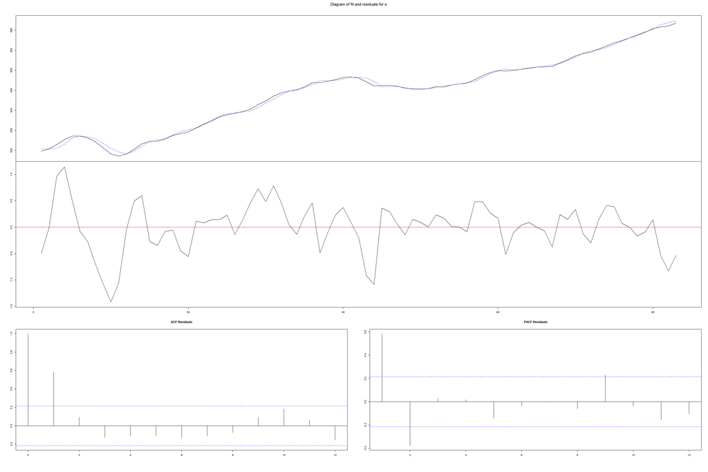

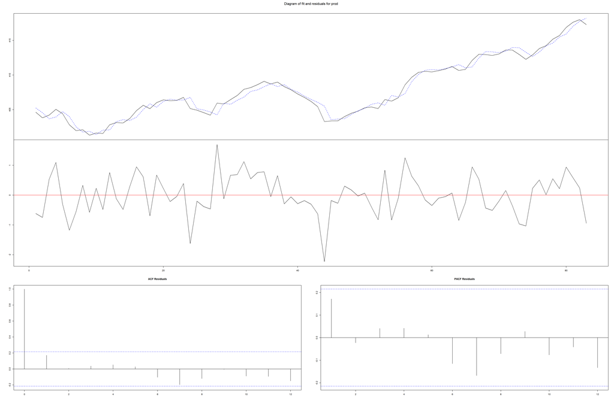

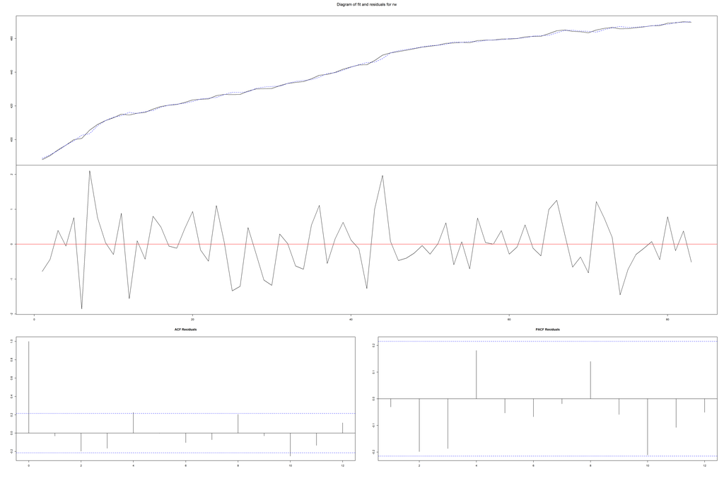

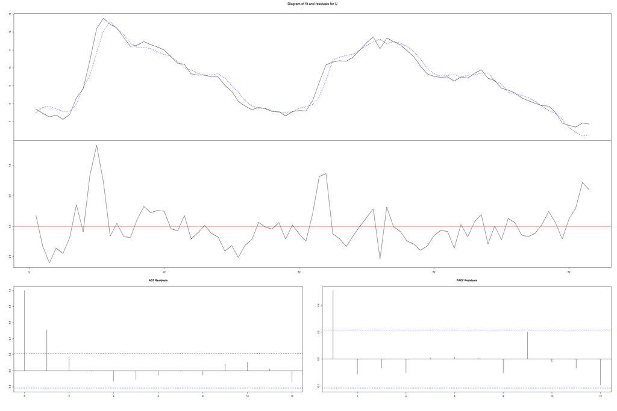

```r
par(mar=c(1,1,1,1))
plot(mod3)
```

```r
tests<-serial.test(mod3,lags.pt=20,type="PT.asymptotic")
tests$serial
```

```
##
##  Portmanteau Test (asymptotic)
##
## data:  Residuals of VAR object mod3
## Chi-squared = 283.9, df = 304, p-value = 0.79
```

```r
arch.mod3<-arch.test(mod3)
arch.mod3
```

```
##
##  ARCH (multivariate)
##
## data:  Residuals of VAR object mod3
## Chi-squared = 570.14, df = 500, p-value = 0.01606
```

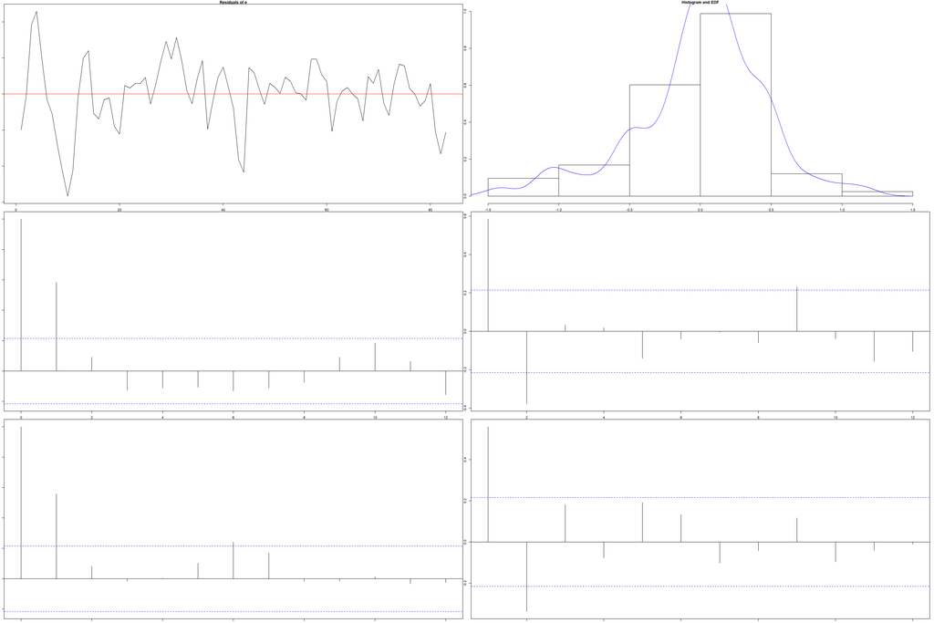

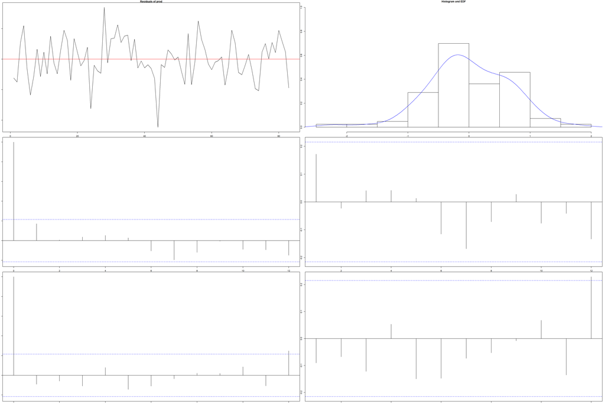

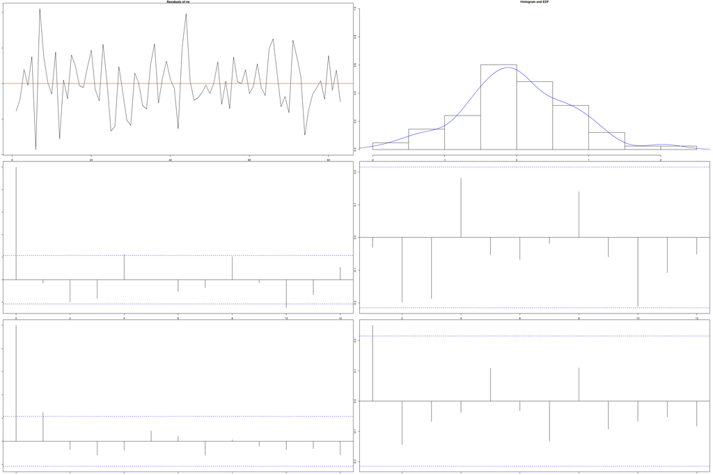

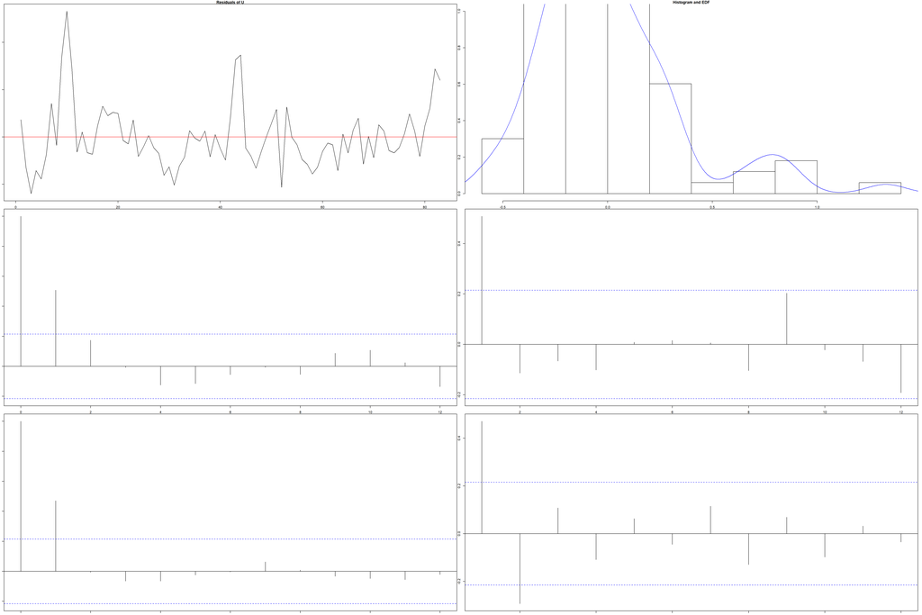

```r
plot(arch.mod3)
```

```r
pred.mod3<-predict(mod3,n.ahead=4,ci=.95)
pred.mod4<-predict(mod4,n.ahead=4,ci=.95)
plot(pred.mod3)
```

[figure not shown]

```r
fanchart(pred.mod3)
```

[figure not shown]

```r
pred.mod3.2<-predict(mod3,n.ahead=4,ci=.99)
plot(pred.mod3.2)
```

[figure not shown]

```r
fanchart(pred.mod3.2)
```

[figure not shown]

```r
plot(pred.mod4)
```

[figure not shown]